# Projet de fin de formation en data analyse chez Google de HINVI Armand Armel

2023-05-21

## Quel est l’origine de l’inflation ?

Pour réaliser cette étude, nous nous sommes basé sur des documents du [site des données de l’ONU](http://data.un.org/)(“Population, surface area and density”,“Consumer price indices” et “Agricultural production indices” ) auxquelles on a apporté quelques modification concernant le [l’IPC au Soudan](https://donnees.banquemondiale.org/pays/soudan), La superficie de [l’Afrique](https://fr.wikipedia.org/wiki/Afrique#:~:text=L%27Afrique%20vue%20de%20l%27espace.%20L%E2%80%99%20Afrique%20est%20un,l%27on%20compte%20l%27%20Am%C3%A9rique%20comme%20un%20seul%20continent.), celle de [l’Amérique](https://fr.wikipedia.org/wiki/Am%C3%A9rique#:~:text=L%27Am%C3%A9rique%20est%20le%20deuxi%C3%A8me%20plus%20grand%20continent%20de,%2856%20%C2%BA%20S%2C%20Terre%20de%20Feu%2C%20Chili%20%29.), celle de [l’Asie](https://fr.wikipedia.org/wiki/Asie#:~:text=L%27%20Asie%20est%20l%27un%20des%20continents%20ou%20une,peupl%C3%A9%20%28environ%2060%20%25%20de%20la%20population%20mondiale%29.) et celle de [l’Europe](https://fr.wikipedia.org/wiki/G%C3%A9ographie_de_l%27Europe#:~:text=L%27Europe%20a%20une%20superficie%20d%27un%20peu%20plus%20de,Sud%2C%20Europe%20de%20l%27Ouest%20et%20Europe%20du%20Nord.).En annexe la description du nettoyage des données

De nos jours, personne n’ignore l’inflation de plus en plus croissante. Nous avons décidé afin de prévoir la descente ou pas des prix de faire une étude sur le sujet. **L’hypothèse faite et sur laquelle s’est basée notre étude est que l’inflation est due à l’augmentation de la population mondiale**.

## Etude de l’évolution de la population mondiale par continent

Population Mondiale

| Annee | Population.Totale..millions. | Moins.de.14.ans..millions. | Plus.de.60.ans..millions. |
| --- | --- | --- | --- |
| 2010 | 6985.60 | 1893.098 | 775.4016 |
| 2015 | 7426.60 | 1960.622 | 913.4718 |
| 2020 | 7840.95 | 2015.124 | 1058.5283 |
| 2022 | 7975.11 | 2017.703 | 1108.5403 |

# Graphique de l’évolution de la population mondiale

La population mondiale tend vers les 8 milliards de personnes et si rien n’est fait, c’est une courbe linéaire qui ne fera qu’augmenter

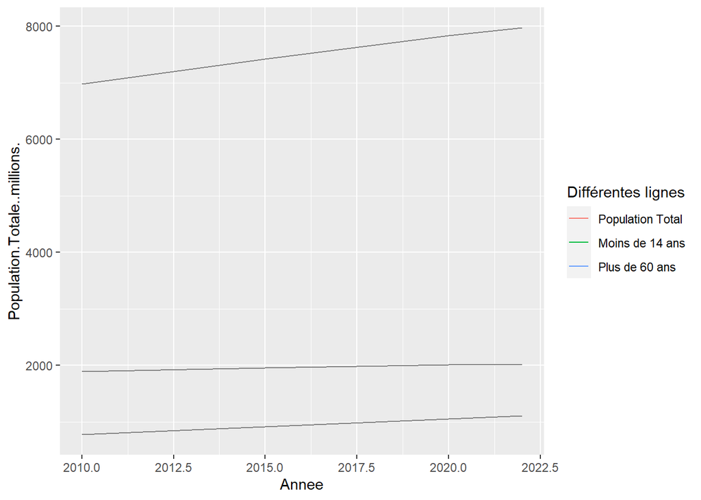

Cette population est répartie comme suit:

Répartition de la population

| Continent | Population.2020..millions. | Population.2022..millions. | Density.2020 | Density.2022 | Surface..million.de.Km2. |
| --- | --- | --- | --- | --- | --- |
| Africa | 1360.68 | 1426.74 | 46.0 | 48.3 | 30.415 |
| Americas | 1025.79 | 1037.14 | 26.4 | 26.7 | 42.437 |
| Asia | 4664.32 | 4722.63 | 148.7 | 150.6 | 43.810 |
| Europe | 746.23 | 743.56 | 33.8 | 33.7 | 10.392 |
| Oceania | 43.93 | 45.04 | 5.2 | 5.3 | 8.486 |

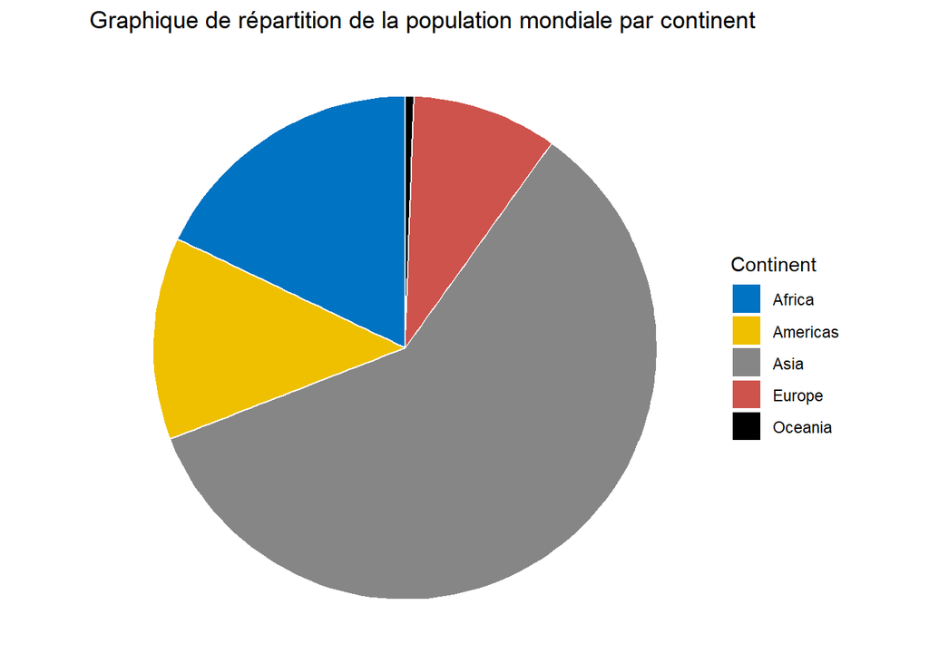

## Etude de l’impact de l’accroissement de la population

L’Indice de Production Agricole (IPA) est selon Google l’indice des prix à la production des produits agricoles qui est basé sur les ventes des produits agricoles livrés hors de la branche agricole. Ci dessous l’évolution des IPA de chaque continent

Indice de Production Agricole

| Annee | ProdAgricAfrica | ProdAgricAmericas | ProdAgricAsia | ProdAgricEurope | ProdAgricOceania | ProdAgricTotal | ProdAlimAfrica | ProdAlimAmericas | ProdAlimAsia | ProdAlimEurope | Oceania | ProdAlimTotal |
| --- | --- | --- | --- | --- | --- | --- | --- | --- | --- | --- | --- | --- |
| 1985 | 38.6 | 55.0 | 37.1 | 108.9 | 63.6 | 52.6 | 37.2 | 53.9 | 36.8 | 106.8 | 58.7 | 52.1 |
| 1995 | 50.2 | 63.0 | 55.8 | 88.1 | 73.1 | 62.1 | 49.1 | 62.3 | 55.6 | 87.9 | 69.5 | 61.9 |
| 2005 | 72.5 | 80.9 | 75.7 | 90.0 | 87.2 | 79.0 | 71.6 | 80.2 | 75.6 | 89.8 | 85.6 | 78.7 |
| 2010 | 85.5 | 90.0 | 88.4 | 90.5 | 86.4 | 88.8 | 85.3 | 89.9 | 88.1 | 90.6 | 86.6 | 88.6 |
| 2015 | 100.5 | 99.3 | 100.2 | 99.8 | 100.5 | 100.0 | 100.6 | 99.4 | 100.3 | 99.8 | 101.1 | 100.1 |
| 2018 | 107.7 | 105.1 | 106.1 | 102.0 | 100.4 | 105.3 | 107.5 | 104.7 | 106.2 | 102.0 | 99.0 | 105.2 |
| 2020 | 112.1 | 108.1 | 108.2 | 102.8 | 91.9 | 107.4 | 111.9 | 107.7 | 107.6 | 102.8 | 93.7 | 107.1 |

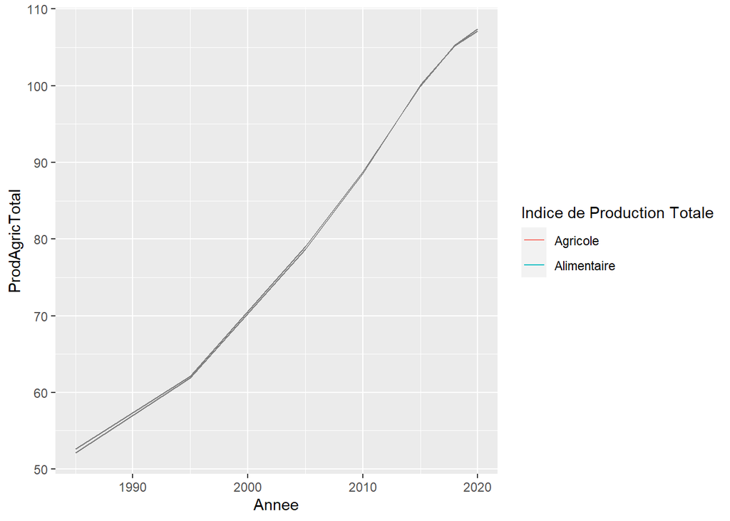

L’Indice du Prix à la Consommation est selon Google l’instrument de mesure de l’inflation. Il est basé sur l’observation d’un panier fixe de biens et services, actualisé chaque année. Il permet de mesurer l’évolution de la valeur de la monnaie et du niveau moyen des prix des produits consommés par les ménages.

Qui dit IPA élevé dit forcément que les consommateurs paierons plus. Voyons si Les pays Africains détiennent le records des IPC

Valeurs moyennes de l’indice du Prix à la consommation

|  | Continent.Pays | IPC.General.2000 | IPC.General.2005 | IPC.General.2010 | IPC.General.2015 | IPC.General.2019 | IPC.General.2020 | IPC.General.2021 |
| --- | --- | --- | --- | --- | --- | --- | --- | --- |
| 153 | Moyenne | 61.62303 | 75.95066 | 100 | 124.7191 | 149.7697 | 169.0546 | 277.923 |

De manière générale, l’IPC augmente. 100 était une des valeurs maximale dans les années 2000 en 2020, 100 est devenu une valeur minimale

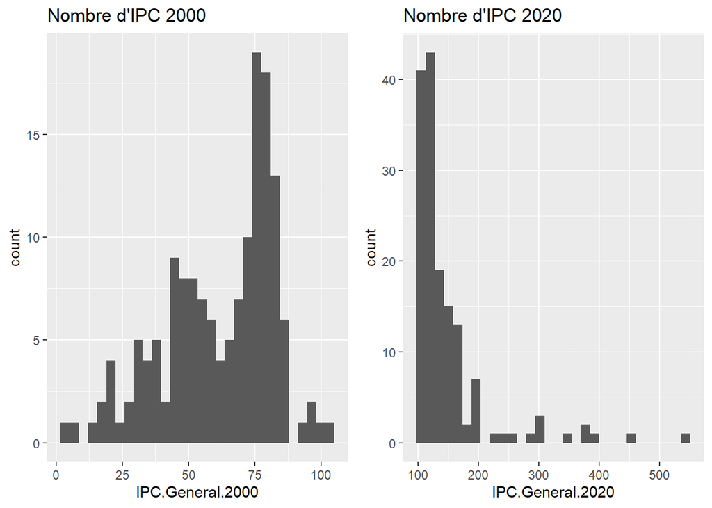

N’ayant pas eu les données des continents, j’ai représenté les variations sur un map. Remarquons que les couleurs clairs qui représentent un IPC élevé sont plus en Afrique que dans les autres régions du globe

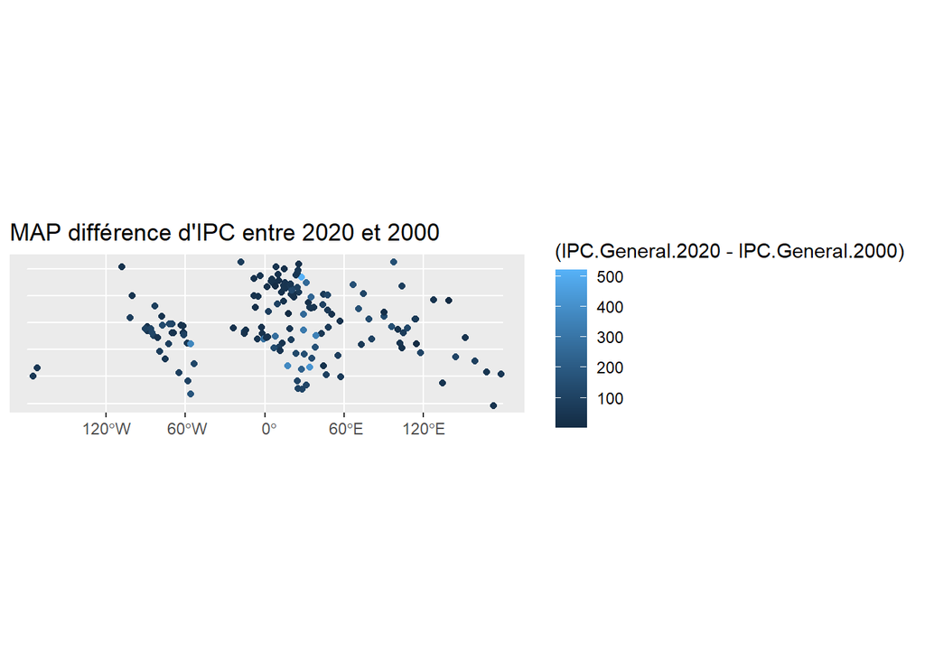

Ci dessous la table des IPC par pays

Indice de Prix à la Consommation

| Continent.Pays | IPC.General.2000 | IPC.General.2005 | IPC.General.2010 | IPC.General.2015 | IPC.General.2019 | IPC.General.2020 | IPC.General.2021 |
| --- | --- | --- | --- | --- | --- | --- | --- |
| Islands | 85.60000 | 90.80000 | 100 | 108.6000 | 113.3000 | 112.8000 | 114.700 |
| Albania | 74.10000 | 86.70000 | 100 | 111.4000 | 119.1000 | 121.0000 | 123.500 |
| Algeria | 70.40000 | 81.80000 | 100 | 126.7000 | 151.4000 | 155.0000 | 166.200 |
| Angola | 2.90000 | 53.70000 | 100 | 159.4000 | 378.9000 | 378.9000 | 378.900 |
| Anguilla | 68.40000 | 81.00000 | 100 | 105.1000 | 107.1000 | 106.6000 | 108.500 |
| Antigua and Barbuda | 81.10000 | 89.50000 | 100 | 110.3000 | 115.4000 | 116.2000 | 118.600 |
| Armenia | 65.00000 | 76.40000 | 100 | 124.8000 | 129.2000 | 130.7000 | 140.100 |
| Aruba | 72.00000 | 84.10000 | 100 | 103.4000 | 109.2000 | 107.8000 | 108.600 |
| Australia | 74.40000 | 86.30000 | 100 | 112.0000 | 119.8000 | 120.8000 | 124.300 |
| Austria | 82.60000 | 91.40000 | 100 | 110.7000 | 118.1000 | 119.8000 | 123.100 |
| Azerbaijan | 49.00000 | 61.10000 | 100 | 117.7000 | 156.9000 | 161.2000 | 172.000 |
| Bahamas | 80.00000 | 88.20000 | 100 | 109.6000 | 116.2000 | 116.3000 | 116.300 |
| Bahrain | 83.40000 | 87.50000 | 100 | 110.6000 | 118.8000 | 116.1000 | 115.300 |
| Bangladesh | 53.90000 | 69.20000 | 100 | 144.6000 | 179.7000 | 189.9000 | 200.400 |
| Belarus | 16.00000 | 61.70000 | 100 | 387.0000 | 508.1000 | 536.2000 | 586.900 |
| Belgium | 81.40000 | 90.40000 | 100 | 108.6000 | 117.1000 | 118.0000 | 120.900 |
| Belize | 77.90000 | 88.30000 | 100 | 103.8000 | 106.2000 | 106.3000 | 109.700 |
| Benin | 74.30000 | 85.40000 | 100 | 109.7000 | 110.7000 | 114.1000 | 116.000 |
| Bhutan | 80.60000 | 74.80000 | 100 | 87.6000 | 100.2000 | 105.8000 | 113.600 |
| Bolivia | 62.60000 | 73.00000 | 100 | 133.7000 | 148.3000 | 149.7000 | 150.800 |
| Botswana | 44.00000 | 64.30000 | 100 | 132.9000 | 149.7000 | 152.6000 | 162.800 |
| Brazil | 52.50000 | 79.50000 | 100 | 138.4000 | 167.4000 | 172.8000 | 187.100 |
| Brunei Darussalam | 95.00000 | 95.50000 | 100 | 99.9000 | 99.0000 | 100.9000 | 102.700 |
| Bulgaria | 56.10000 | 72.70000 | 100 | 106.6000 | 114.4000 | 116.3000 | 120.200 |
| Burkina Faso | 74.90000 | 86.90000 | 100 | 107.8000 | 108.4000 | 110.4000 | 114.400 |
| Burundi | 41.90000 | 61.30000 | 100 | 154.0000 | 182.1000 | 195.4000 | 211.900 |
| Cabo Verde | 78.70000 | 82.60000 | 100 | 108.6000 | 110.5000 | 111.2000 | 113.200 |
| Cambodia | 61.00000 | 68.20000 | 100 | 117.5000 | 130.1000 | 133.9000 | 137.900 |
| Cameroon | 77.60000 | 85.70000 | 100 | 112.9000 | 118.6000 | 121.5000 | 124.300 |
| Canada | 81.90000 | 91.90000 | 100 | 108.7000 | 116.8000 | 117.6000 | 121.600 |

[output cut: 123 more lines]

# Nettoyage des données

*Permettez que je sois synthétique en factorisant les taches éffectuées*

- Suppression des champs Sources et Footnote
- Filtrage des données et conservations des données continentales pour deux tables. La troisième, celle des IPC contient des données par pays aucune donnée continentale
- Mise en colonne des données avec RECHERCHEV et pour certaines données RECHERCHEV(CONCATENER…) après avoir concatené les champs de recherche
- Collage spécial pour éliminer les formules
- Suppression des lignes contenant les données transposées Changement des types de données
- Recherche sur les données abérantes comme les données du Soudan et les superficies des continents
- Certaines données étaient manquants dans la table des IPC j’ai du dupliquer les valeurs d’IPC du même pays en agricole et en alimentaire
- Renommage des pays dont les noms contiennent des accents ou le mot république afin de pouvoir récupérer leurs coordonnées géographiques
- Transposition des tableaux sauf celui de l’IPC

*Merci pour votre attention*